# Case Study: How can a Wellness Technology Company Play it Smart?

EamonC

2022-12-22

### Analyze

In this step we will analyze the data in order to establish trends, and relationships, thus providing insights that will help answer business questions.

Key Tasks:

- Create summary statistics
- Aggregate the data so it’s useful and accessible
- Clean, organise, transform and format the data
- Perform calculations
- Explore and identify trends and relationships and visualise them
- Highlight observations and opportunities for app and business improvements

For Python analysis in Jupyter Notebook: https://eamoned.github.io/google-data-analytics-casestudy-python-analyse/

A full report on processing the datasets (and final transformations) can be found here: https://eamoned.github.io/google-data-analytics-casestudy-process/

###### Load Packages

```r
library(ggplot2)
library(Hmisc)
library(dplyr)
library(patchwork)
library(reshape2)
library(gridExtra)
library(ggcorrplot)
library(reshape2)
library(ggbeeswarm)
library("tidyverse")
```

###### Import & describe the data

```r
dailyAct <- read.csv("clean_data/dailyActivity.csv")
```

```r
str(dailyAct)
```

```
## 'data.frame':    940 obs. of  14 variables:
##  $ Id                      : num  1.5e+09 1.5e+09 1.5e+09 1.5e+09 1.5e+09 ...
##  $ ActivityDate            : chr  "2016-04-12" "2016-04-13" "2016-04-14" "2016-04-15" ...
##  $ TotalSteps              : int  13162 10735 10460 9762 12669 9705 13019 15506 10544 9819 ...
##  $ TotalDistance           : num  8.5 6.97 6.74 6.28 8.16 ...
##  $ LoggedActivitiesDistance: num  0 0 0 0 0 0 0 0 0 0 ...
##  $ VeryActiveDistance      : num  1.88 1.57 2.44 2.14 2.71 ...
##  $ ModeratelyActiveDistance: num  0.55 0.69 0.4 1.26 0.41 ...
##  $ LightActiveDistance     : num  6.06 4.71 3.91 2.83 5.04 ...
##  $ SedentaryActiveDistance : num  0 0 0 0 0 0 0 0 0 0 ...
##  $ VeryActiveMinutes       : int  25 21 30 29 36 38 42 50 28 19 ...
##  $ FairlyActiveMinutes     : int  13 19 11 34 10 20 16 31 12 8 ...
##  $ LightlyActiveMinutes    : int  328 217 181 209 221 164 233 264 205 211 ...
##  $ SedentaryMinutes        : int  728 776 1218 726 773 539 1149 775 818 838 ...
##  $ Calories                : int  1985 1797 1776 1745 1863 1728 1921 2035 1786 1775 ...
```

```r
dim(dailyAct)
```

```
## [1] 940  14
```

```r
summary(dailyAct)
```

```
##        Id            ActivityDate         TotalSteps    TotalDistance
##  Min.   :1.504e+09   Length:940         Min.   :    0   Min.   : 0.000
##  1st Qu.:2.320e+09   Class :character   1st Qu.: 3790   1st Qu.: 2.620
##  Median :4.445e+09   Mode  :character   Median : 7406   Median : 5.245
##  Mean   :4.855e+09                      Mean   : 7638   Mean   : 5.490
##  3rd Qu.:6.962e+09                      3rd Qu.:10727   3rd Qu.: 7.713
##  Max.   :8.878e+09                      Max.   :36019   Max.   :28.030
##  LoggedActivitiesDistance VeryActiveDistance ModeratelyActiveDistance
##  Min.   :0.0000           Min.   : 0.000     Min.   :0.0000
##  1st Qu.:0.0000           1st Qu.: 0.000     1st Qu.:0.0000
##  Median :0.0000           Median : 0.210     Median :0.2400
##  Mean   :0.1082           Mean   : 1.503     Mean   :0.5675
##  3rd Qu.:0.0000           3rd Qu.: 2.053     3rd Qu.:0.8000
##  Max.   :4.9421           Max.   :21.920     Max.   :6.4800
##  LightActiveDistance SedentaryActiveDistance VeryActiveMinutes
##  Min.   : 0.000      Min.   :0.000000        Min.   :  0.00
##  1st Qu.: 1.945      1st Qu.:0.000000        1st Qu.:  0.00
##  Median : 3.365      Median :0.000000        Median :  4.00
##  Mean   : 3.341      Mean   :0.001606        Mean   : 21.16
##  3rd Qu.: 4.782      3rd Qu.:0.000000        3rd Qu.: 32.00
##  Max.   :10.710      Max.   :0.110000        Max.   :210.00
##  FairlyActiveMinutes LightlyActiveMinutes SedentaryMinutes    Calories
##  Min.   :  0.00      Min.   :  0.0        Min.   :   0.0   Min.   :   0
##  1st Qu.:  0.00      1st Qu.:127.0        1st Qu.: 729.8   1st Qu.:1828
##  Median :  6.00      Median :199.0        Median :1057.5   Median :2134
##  Mean   : 13.56      Mean   :192.8        Mean   : 991.2   Mean   :2304
##  3rd Qu.: 19.00      3rd Qu.:264.0        3rd Qu.:1229.5   3rd Qu.:2793
##  Max.   :143.00      Max.   :518.0        Max.   :1440.0   Max.   :4900
```

```r
print(paste0("Number of unique Ids: " ,length(unique(dailyAct$Id))))
```

```
## [1] "Number of unique Ids: 33"
```

```r
print(paste0("There are " ,length(unique(dailyAct$ActivityDate)), " days of data"))
```

```
## [1] "There are 31 days of data"
```

```r
print(paste0("Are there any NAs = ",any(is.na(dailyAct))))
```

```
## [1] "Are there any NAs = FALSE"
```

###### Activity Levels (Distance)

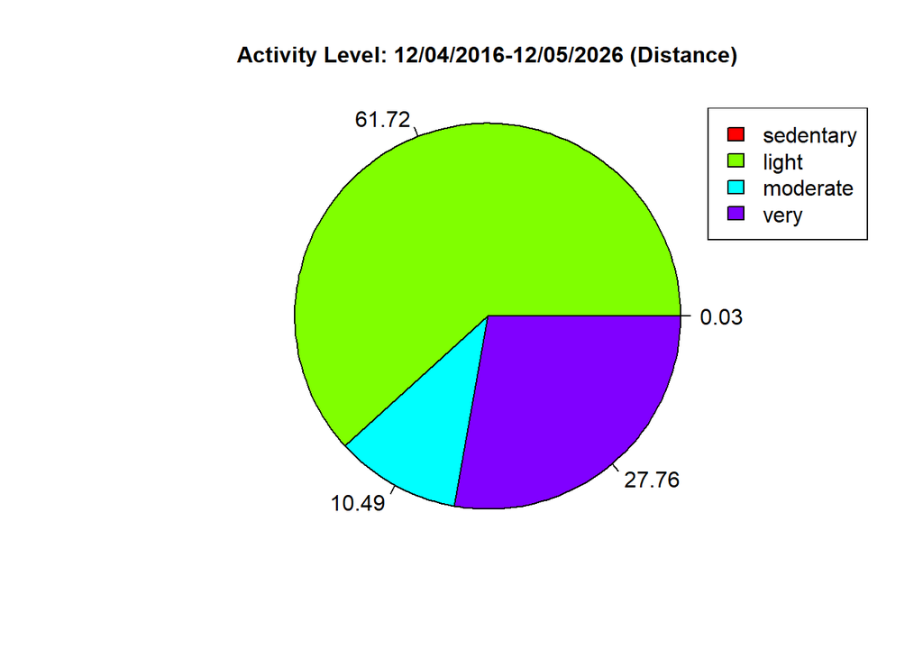

```r
# create data frame for activity percentage (Distance)
# total distance for each level
Level <-  c("sedentary", "light", "moderate", "very")
Distance <- c(sum(dailyAct$SedentaryActiveDistance),
              sum(dailyAct$LightActiveDistance),
              sum(dailyAct$ModeratelyActiveDistance),
              sum(dailyAct$VeryActiveDistance))

# Plot Pie chart for Distance
piepercent<- round(100*(Distance/sum(Distance)), 2)
pie(Distance, radius=1, labels = piepercent, col = rainbow(length(Distance)),
    main = "Activity Level: 12/04/2016-12/05/2026 (Distance)", cex.main = 1)
legend("topright", Level,fill = rainbow(length(Distance)))
```

###### Activity Levels (Minutes)

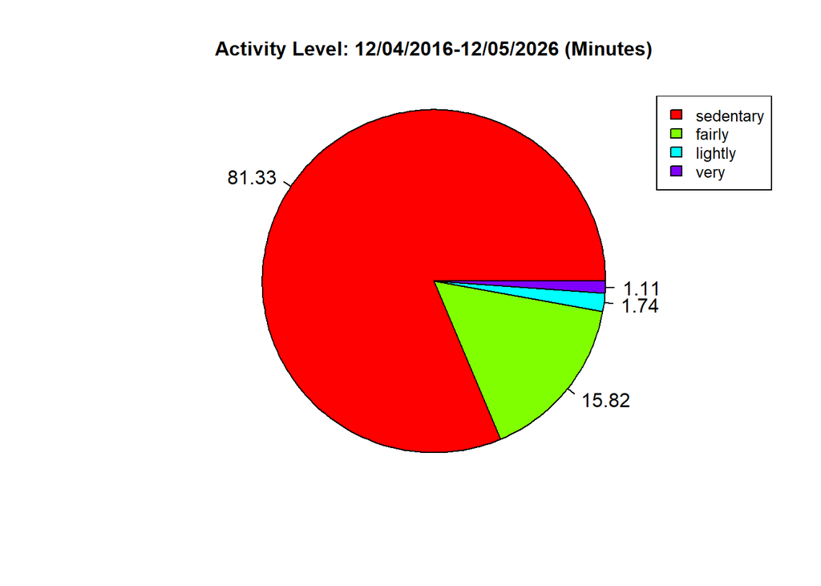

```r
# Create data frame for activity percentage (Minutes)
# Total Minutes for each Level
Level2 <- c('sedentary','fairly', 'lightly', 'very')
Minutes <- c(sum(dailyAct$SedentaryMinutes),
             sum(dailyAct$LightlyActiveMinutes),
             sum(dailyAct$VeryActiveMinutes),
             sum(dailyAct$FairlyActiveMinutes))

# Plot Pie Chart for Minutes
piepercent<- round(100*(Minutes/sum(Minutes)), 2)
pie(Minutes, radius=1, labels = piepercent, col = rainbow(length(Minutes)),
    main = "Activity Level: 12/04/2016-12/05/2026 (Minutes)", cex.main = 1)
legend("topright",Level2, cex = 0.8,fill = rainbow(length(Minutes)))
```

###### Distributions

For Light, moderate and very active, zero distance is not relevant so lets remove zeros (has some impact on mean)

Removing zeros distance will make a difference to the mean

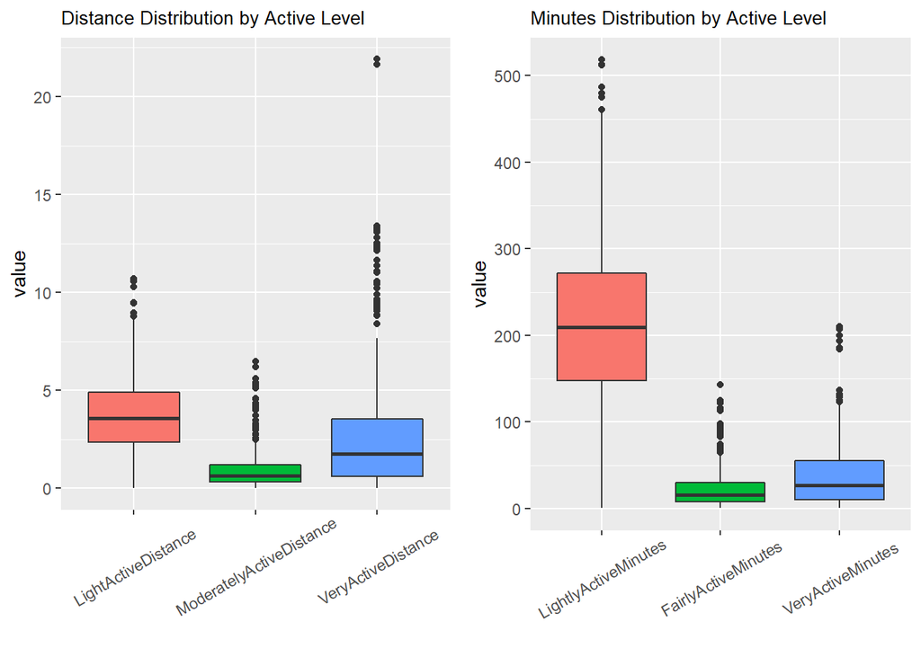

```r
activityDist <- subset(dailyAct, select=c("ActivityDate", "LightActiveDistance","ModeratelyActiveDistance", "VeryActiveDistance"))
activityDist <- melt(activityDist, id.vars = "ActivityDate", variable.name="level")
# remove zeros
activityDist[activityDist == 0] <- NA

activityMins <- subset(dailyAct,select=c("ActivityDate","LightlyActiveMinutes",
                                         "FairlyActiveMinutes", "VeryActiveMinutes"))
activityMins <- melt(activityMins, id.vars = "ActivityDate", variable.name="level")
# remove zeros
activityMins[activityMins == 0] <- NA

z1 <- ggplot(activityDist, aes(x=level,y=value, fill=level)) +
  geom_boxplot() +
  labs(title="Distance Distribution by Active Level", x="") +
  theme(legend.position="none")+
  theme(plot.title = element_text(size = 10)) +
  theme(axis.text.x = element_text(angle = 30, vjust=+0.55))

z2 <- ggplot(activityMins, aes(x=level,y=value, fill=level)) +
  geom_boxplot() +
  labs(title="Minutes Distribution by Active Level", x="") +
  theme(legend.position="none")+
  theme(plot.title = element_text(size = 10)) +
  theme(axis.text.x = element_text(angle = 30, vjust=+0.55))

grid.arrange(z1, z2, nrow = 1)
```

###### Summary

```
## [1] "Average Daily Distance = 5.48970212191541"
```

```
## [1] "Average Daily Steps = 7637.91063829787"
```

```
## [1] "Average Daily Calories = 2303.60957446809"
```

```
## [1] "Percentage light active distance: 60.8561097559676"
```

```
## [1] "Percentage moderate active distance: 10.3383123303724"
```

```
## [1] "Percentage very active distance: 27.3727210990392"
```

```
## [1] "Percentage sedentary active distance: 0.0292617508384631"
```

```
## [1] "Percentage lightly active minutes:84.7370143531722"
```

```
## [1] "Percentage fairly active minutes: 5.96147552480247"
```

```
## [1] "Percentage very active minutes: 9.30151012202534"
```

#### Obervations:

Activity Levels:

- Just over 61% of total distance achieved is through light active activities. This is followed by 28% very active distance activities. Only 10% is achieved through moderate activities. Perhaps there’s an opportunity to encourage people to plan & set goals to achieve higher activity levels which will in turn burn more calories and improve fitness.
- In percentage terms for minutes spent on activities, Lightly has almost 85%, followed by very and then fairly active.

#### Opportunities:

- Additional features which allow users to plan and set targets (with alerts) for times and distances at the different levels of activity. For example, increase or set higher targets for the percentage of time spent in the “fairly” to “Very” active levels. Or, increase the distance in the moderate to very active levels of exercise.

###### Calories and Activity levels over time

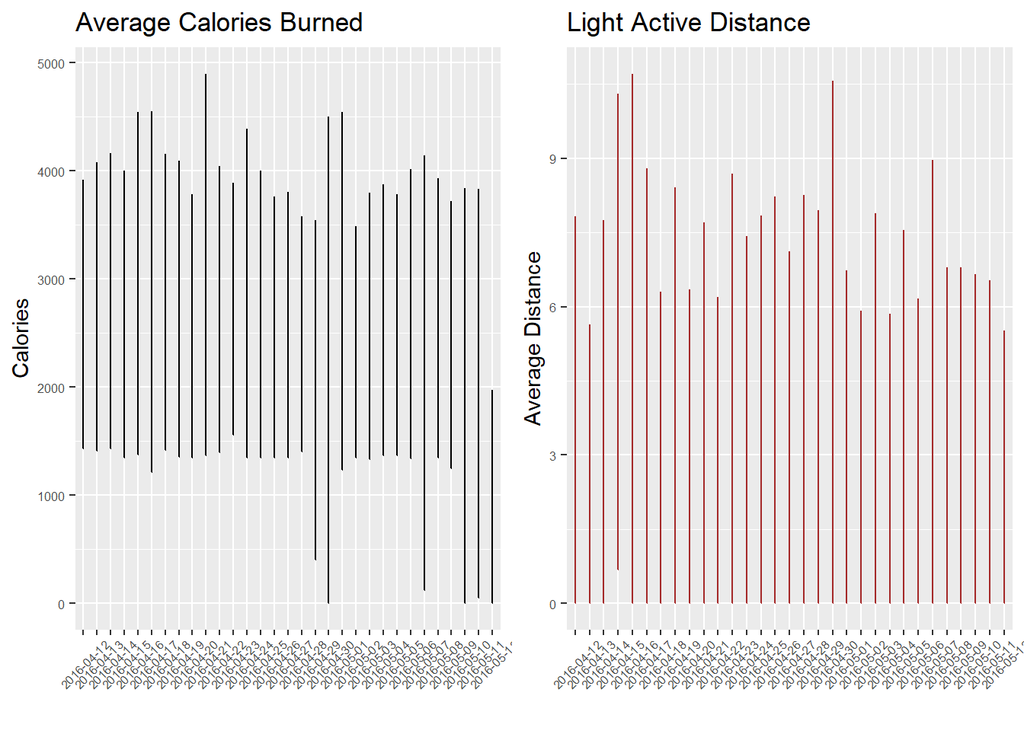

```r
# Calories
a1 <- ggplot(dailyAct, aes(x=as.character(ActivityDate), y = Calories))+
  geom_line(stat="identity") +
  ggtitle("Average Calories Burned") +
  labs(x="", y="Calories") +
  theme(axis.text.x = element_text(angle = 45, vjust=+0.55),
        axis.text=element_text(size=6))

# Distance
a21 <- ggplot(dailyAct, aes(x=as.character(ActivityDate), y = LightActiveDistance))+
  geom_line(stat="identity", color = "brown") +
  ggtitle('Light Active Distance') +
  labs(x="", y="Average Distance") +
  theme(axis.text.x = element_text(angle = 45, vjust=+0.55),
        axis.text=element_text(size=6))

a22 <- ggplot(dailyAct, aes(x=as.character(ActivityDate), y = ModeratelyActiveDistance))+
  geom_line(stat="identity", color = "blue") +
  ggtitle('Moderately Active Distance') +
  labs(x="", y="Average Distance") +
  theme(axis.text.x = element_text(angle = 45, vjust=+0.55),
        axis.text=element_text(size=6))

a23 <- ggplot(dailyAct, aes(x=as.character(ActivityDate), y = VeryActiveDistance))+
  geom_line(stat="identity", color = "red") +
  ggtitle('Very Active Distance') +
  labs(x="", y="") +
  theme(axis.text.x = element_text(angle = 45, vjust=+0.55),
        axis.text=element_text(size=6))

# Minutes
a24 <- ggplot(dailyAct, aes(x=as.character(ActivityDate), y = LightlyActiveMinutes))+
  geom_line(stat="identity", color = "brown") +
  ggtitle('Lightly Active Minutes') +
  labs(x="", y="Average Minutes") +
  theme(axis.text.x = element_text(angle = 45, vjust=+0.55),
        axis.text=element_text(size=6))

a25 <- ggplot(dailyAct, aes(x=as.character(ActivityDate), y = FairlyActiveMinutes))+
  geom_line(stat="identity", color = "blue") +
  ggtitle('Fairly Active Minutes') +
  labs(x="", y="Average Minutes") +
  theme(axis.text.x = element_text(angle = 45, vjust=+0.55),
        axis.text=element_text(size=6))

a26 <- ggplot(dailyAct, aes(x=as.character(ActivityDate), y = VeryActiveMinutes))+
  geom_line(stat="identity", color = "red") +
  ggtitle('Very Active Minutes') +
  labs(x="", y="Average Minutes") +
  theme(axis.text.x = element_text(angle = 45, vjust=+0.55),
        axis.text=element_text(size=6))

grid.arrange(a1, a21, nrow = 1)
```

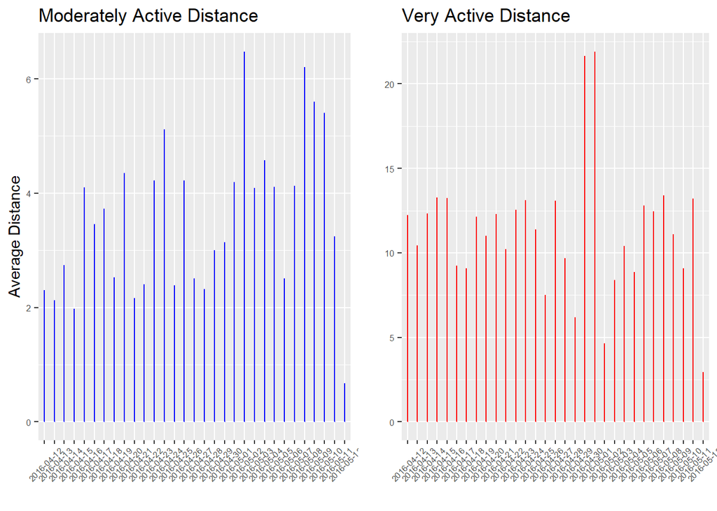

```r
grid.arrange(a22, a23, nrow = 1)
```

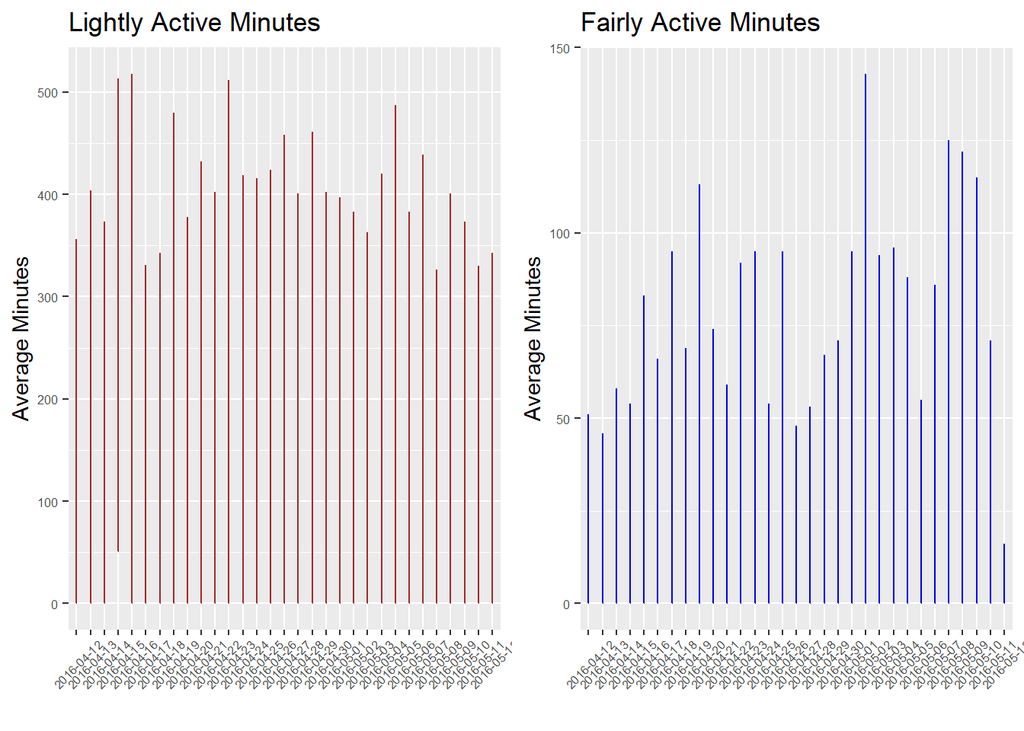

```r
grid.arrange(a24, a25, nrow = 1)
```

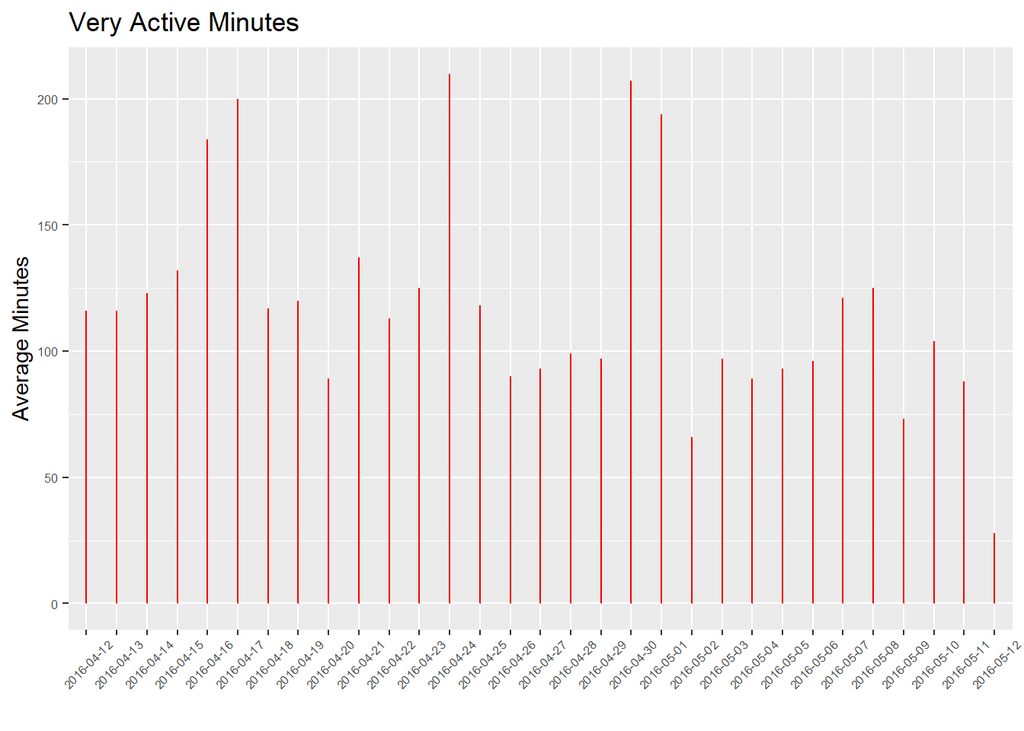

```r
grid.arrange(a26, nrow = 1)
```

#### Opportunities:

- The app could determine the users base line fitness and goals (e.g. lose weight, improve fitness) and then provide a fitness plan on activity levels (light, fairly, very), activity minutes, and activity distance required, with targets, to achieve that level or goal.

To support visualisations, lets format the datetime, and create a DayName column from the datetime.

```r
# change to date format
dailyAct$ActivityDate <- as.POSIXct(dailyAct$ActivityDate, format="%Y-%m-%d")
# order the date
dailyAct <-dailyAct[order(dailyAct$ActivityDate),]
# Create a DayName column from the datetime
dailyAct$DayName <- weekdays(dailyAct$ActivityDate)
unique(dailyAct$DayName)
```

```
## [1] "Tuesday"   "Wednesday" "Thursday"  "Friday"    "Saturday"  "Sunday"
## [7] "Monday"
```

```r
# change DayName to a factor, i.e. for day order - Tues, Wed, etc)
dailyAct$DayName <- factor(dailyAct$DayName, levels = c("Tuesday", "Wednesday", "Thursday",
                                                        "Friday", "Saturday","Sunday","Monday"))
```

###### Calorie, Steps & Distance means/medians for Days

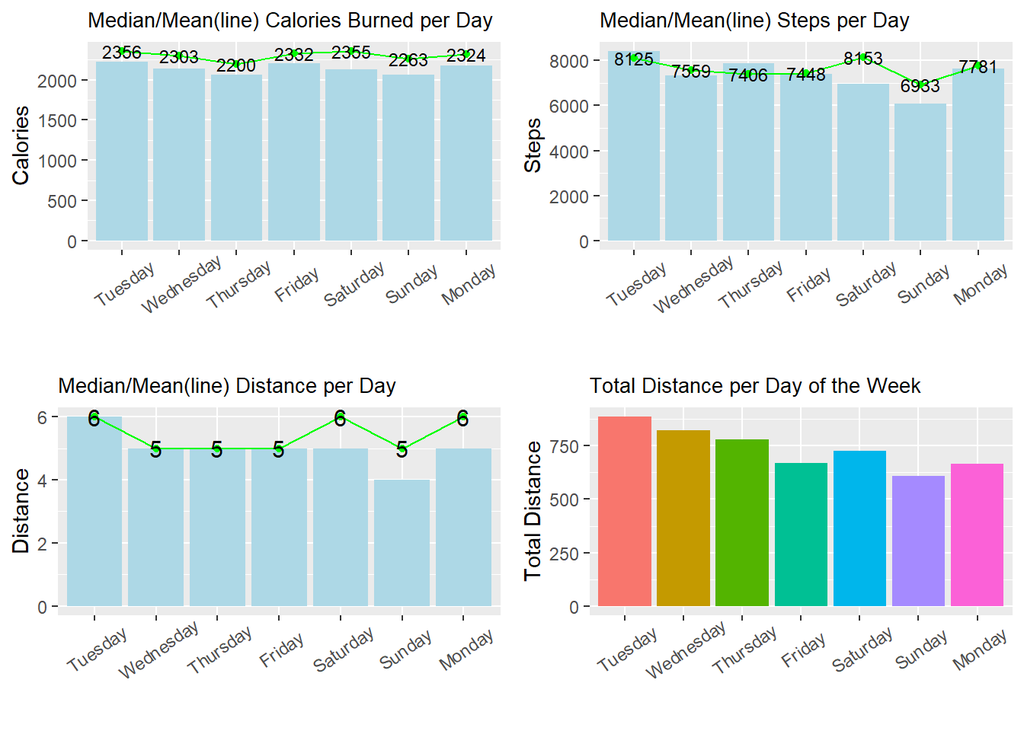

```r
# Calculate average/median Calories for Day Name
calMean <- dailyAct %>%
  group_by(DayName) %>%
    summarise(meanCals = round(mean(Calories),0),
              medianCals = round(median(Calories),0))

# Calculate average/median Steps for Day Name
stepsMean <- dailyAct %>%
  group_by(DayName) %>%
  summarise(meanSteps = round(mean(TotalSteps),0),
            medianSteps = round(median(TotalSteps),0))

# Calculate Average/median Distance for Day Name
distMean <- dailyAct %>%
  group_by(DayName) %>%
  summarise(sumDist = round(sum(TotalDistance),0),
            meanDist = round(mean(TotalDistance),0),
            medianDist = round(median(TotalDistance),0))

b1 <- ggplot(calMean, aes(x=DayName, y=medianCals)) +
  geom_bar(stat="identity", fill="lightblue") +
  geom_line(aes(x=DayName,y=meanCals,group=1), stat="identity", color = "green") +
  geom_point(color = "green", aes(x=DayName,y=meanCals)) +
  theme(legend.position = "none") +
  geom_text(size=3,aes(label=meanCals, x=DayName, y=meanCals), colour="black") +
  ggtitle("Median/Mean(line) Calories Burned per Day")+
  theme(plot.title = element_text(size = 10)) +
  ylab("Calories") +
  xlab("") +
  theme(axis.text.x = element_text(angle = 35, vjust=+0.7))

b2 <- ggplot(stepsMean, aes(x=DayName, y=medianSteps)) +
  geom_bar(stat="identity", fill="lightblue") +
  geom_line(aes(x=DayName,y=meanSteps,group=1), stat="identity", color = "green") +
  geom_point(color = "green", aes(x=DayName,y=meanSteps)) +
  theme(legend.position = "none") +
  geom_text(size=3,aes(label=meanSteps, x=DayName, y=meanSteps), colour="black") +
  ggtitle("Median/Mean(line) Steps per Day")+
  theme(plot.title = element_text(size = 10)) +
  ylab("Steps") +
  xlab("") +
  theme(axis.text.x = element_text(angle = 35, vjust=+0.7))

b3 <- ggplot(distMean, aes(x=DayName, y=medianDist)) +
  geom_bar(stat="identity", fill="lightblue") +
  geom_line(aes(x=DayName,y=meanDist,group=1), stat="identity", color = "green") +
  geom_point(color = "green", aes(x=DayName,y=meanDist)) +
  theme(legend.position = "none") +
  geom_text(size=4,aes(label=meanDist, x=DayName, y=meanDist), colour="black") +
  ggtitle("Median/Mean(line) Distance per Day")+
  theme(plot.title = element_text(size = 10)) +
  ylab("Distance") +
  xlab("") +
  theme(axis.text.x = element_text(angle = 35, vjust=+0.7))

b4 <- ggplot(distMean, aes(x=DayName, y=sumDist, fill = DayName)) +
  geom_bar(stat="identity") +
  theme(legend.position = "none") +
  ggtitle("Total Distance per Day of the Week")+
  theme(plot.title = element_text(size = 10)) +
  ylab("Total Distance") +
  xlab("") +
  theme(axis.text.x = element_text(angle = 35, vjust=+0.7))

grid.arrange(b1, b2, b3, b4, nrow = 2)
```

###### Activity Minutes over days of the week

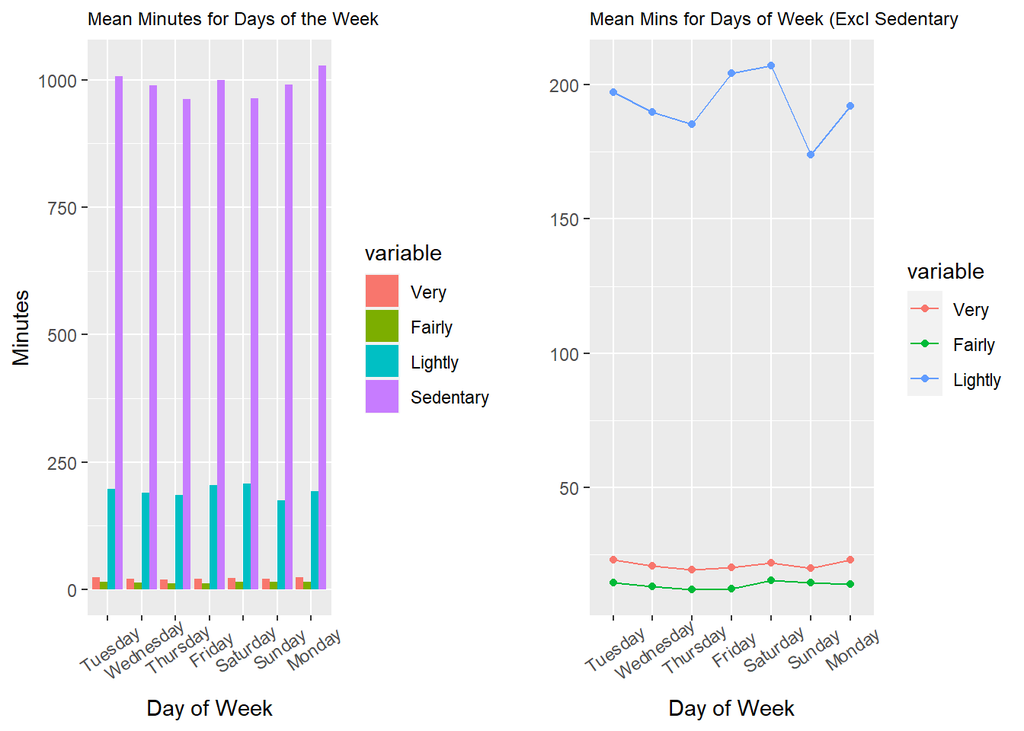

```r
day_mins <- dailyAct %>%
  group_by(DayName) %>%
  summarise(Very = mean(VeryActiveMinutes),
            Fairly = mean(FairlyActiveMinutes),
            Lightly = mean(LightlyActiveMinutes),
            Sedentary = mean(SedentaryMinutes))
day_m <- melt(day_mins, id.vars = "DayName")

c1 <- ggplot(day_m, aes(x=DayName, y = value, fill=variable)) +
  geom_bar(stat="summary", fun=sum, position = position_dodge()) +
  labs(x="Day of Week", y="Minutes") +
  ggtitle("Mean Minutes for Days of the Week") +
  theme(plot.title = element_text(size = 9)) +
  theme(axis.text.x = element_text(angle = 35, vjust=+0.7))

# Excluding Sedentary
day_mins <- dailyAct %>%
  group_by(DayName) %>%
  summarise(Very = mean(VeryActiveMinutes),
            Fairly = mean(FairlyActiveMinutes),
            Lightly = mean(LightlyActiveMinutes))
day_m <- melt(day_mins, id.vars = "DayName")

c2 <- ggplot(day_m, aes(x=DayName, y = value, group=variable, fill=variable)) +
  geom_line(stat="summary", fun=mean, aes(colour = variable)) +
  ggtitle("Mean Mins for Days of Week (Excl Sedentary") +
  geom_point(stat="summary", fun=mean, aes(colour = variable)) +
  labs(x="Day of Week", y="") +
  theme(plot.title = element_text(size = 9)) +
  theme(axis.text.x = element_text(angle = 35, vjust=+0.7))

grid.arrange(c1, c2, nrow = 1)
```

#### Opportunities:

- The app could provide information on low activity periods, and so encourage users to get more active on other days of the week, including weekends. Again this could play a part in the users overall fitness level and goal plan.
- There could be scope in the app for allowing users to plan increases in fairly & very active minutes, and decrease Sedentary minutes. Users could then monitor this or receive badges when goals are meet, or receive alerts when they need to take action.

###### Import & describe the sleep data

```r
act_sleepDay = read.csv("clean_data/act_sleepDay_inner.csv")
```

```r
str(act_sleepDay)
```

```
## 'data.frame':    410 obs. of  17 variables:
##  $ Id                      : num  1.5e+09 1.5e+09 1.5e+09 1.5e+09 1.5e+09 ...
##  $ ActivityDate            : chr  "2016-04-12" "2016-04-13" "2016-04-15" "2016-04-16" ...
##  $ TotalSteps              : int  13162 10735 9762 12669 9705 15506 10544 9819 14371 10039 ...
##  $ TotalDistance           : num  8.5 6.97 6.28 8.16 6.48 ...
##  $ LoggedActivitiesDistance: num  0 0 0 0 0 0 0 0 0 0 ...
##  $ VeryActiveDistance      : num  1.88 1.57 2.14 2.71 3.19 ...
##  $ ModeratelyActiveDistance: num  0.55 0.69 1.26 0.41 0.78 ...
##  $ LightActiveDistance     : num  6.06 4.71 2.83 5.04 2.51 ...
##  $ SedentaryActiveDistance : num  0 0 0 0 0 0 0 0 0 0 ...
##  $ VeryActiveMinutes       : int  25 21 29 36 38 50 28 19 41 39 ...
##  $ FairlyActiveMinutes     : int  13 19 34 10 20 31 12 8 21 5 ...
##  $ LightlyActiveMinutes    : int  328 217 209 221 164 264 205 211 262 238 ...
##  $ SedentaryMinutes        : int  728 776 726 773 539 775 818 838 732 709 ...
##  $ Calories                : int  1985 1797 1745 1863 1728 2035 1786 1775 1949 1788 ...
##  $ TotalSleepRecords       : int  1 2 1 2 1 1 1 1 1 1 ...
##  $ TotalMinutesAsleep      : int  327 384 412 340 700 304 360 325 361 430 ...
##  $ TotalTimeInBed          : int  346 407 442 367 712 320 377 364 384 449 ...
```

```r
dim(act_sleepDay)
```

```
## [1] 410  17
```

```r
summary(subset(act_sleepDay, select=c("TotalTimeInBed","TotalMinutesAsleep")))
```

```
##  TotalTimeInBed  TotalMinutesAsleep
##  Min.   : 61.0   Min.   : 58.0
##  1st Qu.:403.8   1st Qu.:361.0
##  Median :463.0   Median :432.5
##  Mean   :458.5   Mean   :419.2
##  3rd Qu.:526.0   3rd Qu.:490.0
##  Max.   :961.0   Max.   :796.0
```

```r
print(paste0("Are there any NAs = ",any(is.na(act_sleepDay))))
```

```
## [1] "Are there any NAs = FALSE"
```

```r
print(paste0("There are " ,length(unique(act_sleepDay$ActivityDate)), " days of data"))
```

```
## [1] "There are 31 days of data"
```

```r
print(paste0("Number of unique Ids: " ,length(unique(act_sleepDay$Id))))
```

```
## [1] "Number of unique Ids: 24"
```

```r
# Change data format & create day name
act_sleepDay$ActivityDate <- as.POSIXct(act_sleepDay$ActivityDate, format="%Y-%m-%d")
act_sleepDay <- act_sleepDay[order(act_sleepDay$ActivityDate),]
act_sleepDay$DayName <- weekdays(act_sleepDay$ActivityDate)

# Change DayName to a factor
act_sleepDay$DayName <- factor(act_sleepDay$DayName,
                               levels = c("Tuesday", "Wednesday", "Thursday",
                                                        "Friday", "Saturday","Sunday","Monday"))
```

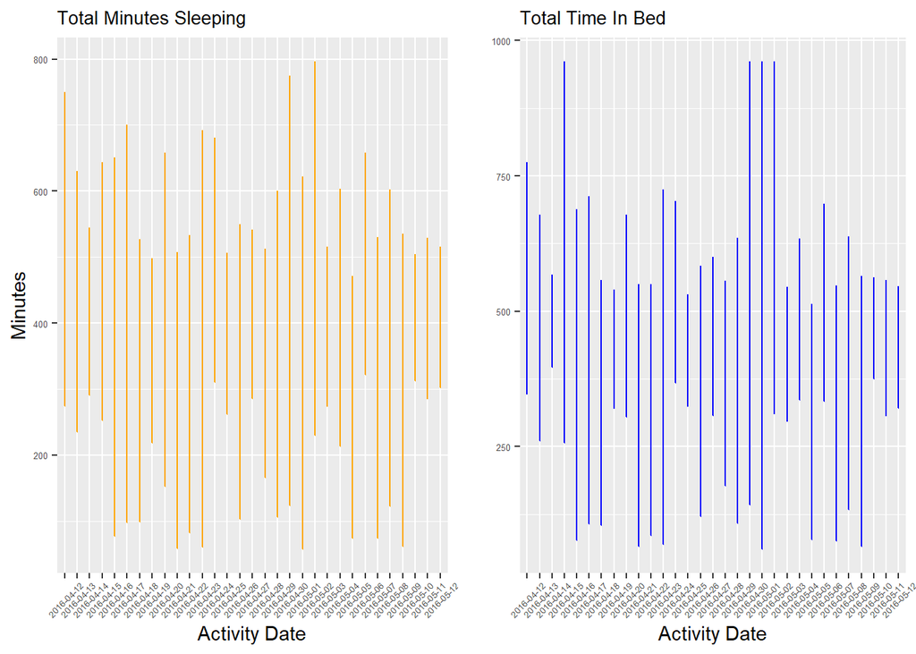

```r
# Time sleeping
d1 <- ggplot(act_sleepDay, aes(x=as.character(ActivityDate), y = TotalMinutesAsleep))+
  geom_line(stat="identity", color = "orange") +
  ggtitle("Total Minutes Sleeping") +
  labs(x="Activity Date", y="Minutes") +
  theme(plot.title = element_text(size = 10)) +
  theme(axis.text.x = element_text(angle = 45, vjust=+0.55),
        axis.text=element_text(size=5))

# Time in bed
d2 <- ggplot(act_sleepDay, aes(x=as.character(ActivityDate), y = TotalTimeInBed))+
  geom_line(stat="identity", color = "blue") +
  ggtitle('Total Time In Bed') +
  labs(x="Activity Date", y="") +
  theme(plot.title = element_text(size = 10)) +
  theme(axis.text.x = element_text(angle = 45, vjust=+0.55),
        axis.text=element_text(size=5))
grid.arrange(d1, d2, nrow = 1)
```

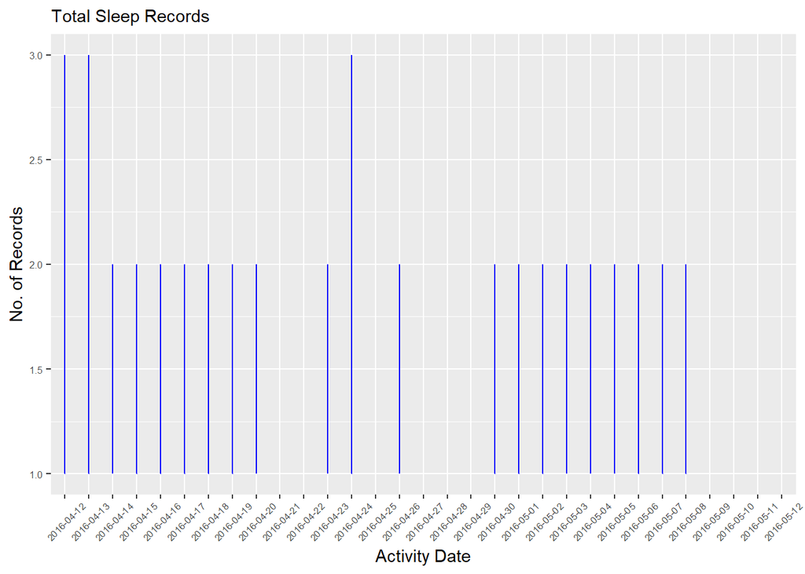

```r
ggplot(act_sleepDay, aes(x=as.character(ActivityDate), y = TotalSleepRecords))+
  geom_line(stat="identity", color = "blue") +
  ggtitle('Total Sleep Records') +
  labs(x="Activity Date", y="No. of Records") +
  theme(plot.title = element_text(size = 11)) +
  theme(axis.text.x = element_text(angle = 45, vjust=+0.55),
        axis.text=element_text(size=6))
```

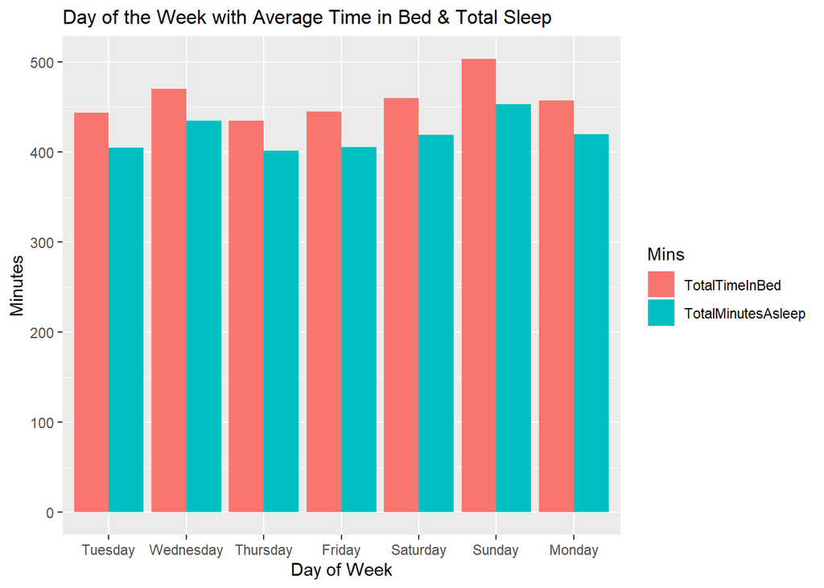

```r
act_avg <- act_sleepDay %>%
  group_by(DayName) %>%
  summarise(TotalTimeInBed = mean(TotalTimeInBed),
            TotalMinutesAsleep = mean(TotalMinutesAsleep))

act_avg <- melt(act_avg, id.vars = "DayName", variable.name="Mins")

ggplot(act_avg, aes(x=DayName, y = value, fill=Mins)) +
  geom_bar(stat="identity", position = position_dodge()) +
  labs(x="Day of Week", y="Minutes") +
  theme(plot.title = element_text(size = 12)) +
  ggtitle("Day of the Week with Average Time in Bed & Total Sleep")
```

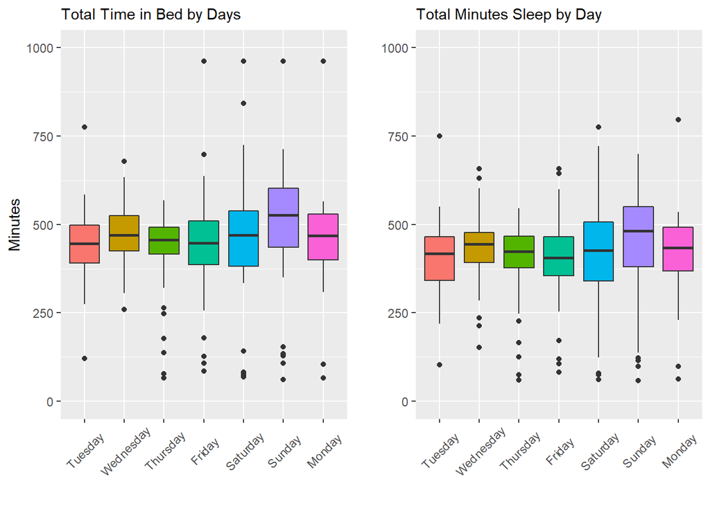

```r
e1 <- ggplot(act_sleepDay, aes(x=DayName,y=TotalTimeInBed, fill=DayName)) +
  geom_boxplot() +
  labs(title="Total Time in Bed by Days", x="", y="Minutes") +
  theme(plot.title = element_text(size = 11)) +
  theme(legend.position="none")+
  theme(axis.text.x = element_text(angle = 45, vjust=+0.55))+
  ylim(0, 1000)


e2 <- ggplot(act_sleepDay, aes(x=DayName,y=TotalMinutesAsleep, fill=DayName)) +
  geom_boxplot() +
  labs(title="Total Minutes Sleep by Day", x="", y="") +
  theme(plot.title = element_text(size = 11)) +
  theme(legend.position="none") +
  theme(axis.text.x = element_text(angle = 45, vjust=+0.55))+
  ylim(0, 1000)

grid.arrange(e1, e2, nrow=1, ncol=2)
```

Lets look at days In bed > 600 minutes and < 240 minutes

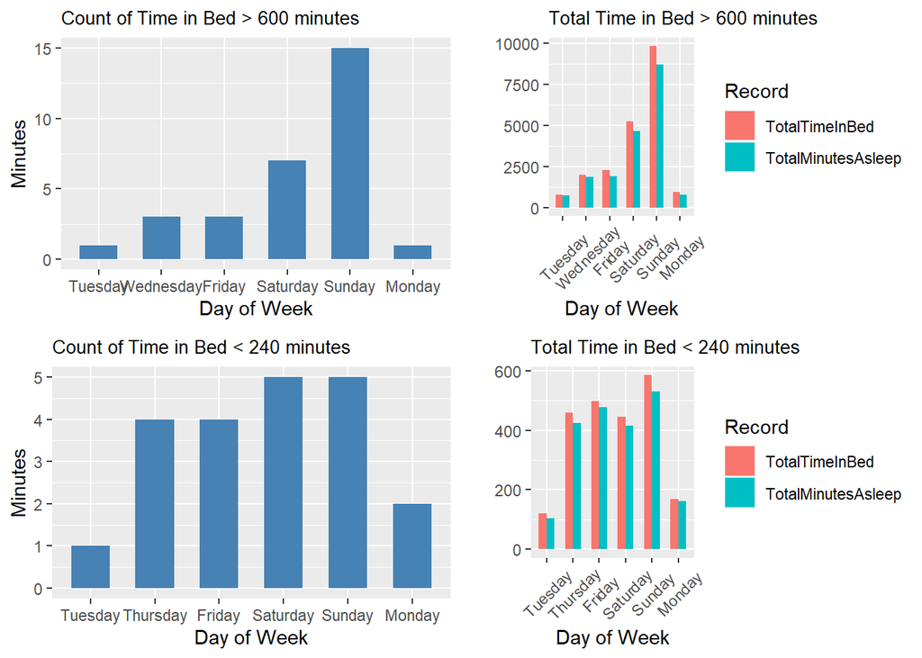

```r
# Lets look at days In bed > 600 minutes in bed

# Count how many time in bed > 600 Minutes (> 10 hours)
topTimeInBed_n <- filter(act_sleepDay, TotalTimeInBed > 600) %>%
  group_by(DayName) %>%
  summarise(countTimeInBed = n())

# Total time in bed & asleep > 600 Minutes (> 10 hours)
topTimeInBed <- filter(act_sleepDay, TotalTimeInBed > 600) %>%
  group_by(DayName) %>%
  summarise(TotalTimeInBed = sum(TotalTimeInBed),
            TotalMinutesAsleep = sum(TotalMinutesAsleep))
topTimeInBed <- melt(topTimeInBed, id.vars = "DayName", variable.name="Record")

f1 <- ggplot(topTimeInBed_n, aes(x=DayName, y = countTimeInBed)) +
  geom_bar(stat="identity", width=0.6,position = position_dodge(), fill="steelblue") +
  labs(x="Day of Week", y="Minutes") +
  ggtitle("Count of Time in Bed > 600 minutes")+
  theme(plot.title = element_text(size = 10))

f2 <- ggplot(topTimeInBed, aes(x=DayName, y = value, fill=Record)) +
  geom_bar(stat="identity", width=0.6,position = position_dodge()) +
  labs(x="Day of Week", y="") +
  ggtitle("Total Time in Bed > 600 minutes")+
  theme(plot.title = element_text(size = 10)) +
  theme(axis.text.x = element_text(angle = 45, vjust=+0.55))


# Lets look at days In bed < 240 minutes

# Count how many time in bed < 240 Minutes (< 4 hours)
lessTimeInBed_n <- filter(act_sleepDay, TotalTimeInBed < 240) %>%
  group_by(DayName) %>%
  summarise(countTimeInBed = n())

# Total time in bed & asleep < 240 Minutes (< 4 hours)
lessTimeInBed <- filter(act_sleepDay, TotalTimeInBed < 240) %>%
  group_by(DayName) %>%
  summarise(TotalTimeInBed = sum(TotalTimeInBed),
            TotalMinutesAsleep = sum(TotalMinutesAsleep))
lessTimeInBed <- melt(lessTimeInBed, id.vars = "DayName", variable.name="Record")

f3 <- ggplot(lessTimeInBed_n, aes(x=DayName, y = countTimeInBed)) +
  geom_bar(stat="identity", width=0.6,position = position_dodge(), fill="steelblue") +
  labs(x="Day of Week", y="Minutes") +
  ggtitle("Count of Time in Bed < 240 minutes")+
  theme(plot.title = element_text(size = 10))

f4 <- ggplot(lessTimeInBed, aes(x=DayName, y = value, fill=Record)) +
  geom_bar(stat="identity", width=0.6,position = position_dodge()) +
  labs(x="Day of Week", y="") +
  ggtitle("Total Time in Bed < 240 minutes")+
  theme(plot.title = element_text(size = 10)) +
  theme(axis.text.x = element_text(angle = 45, vjust=+0.55))

grid.arrange(f1, f2, f3, f4, nrow=2, ncol=2)
```

Number of sleep records > 1

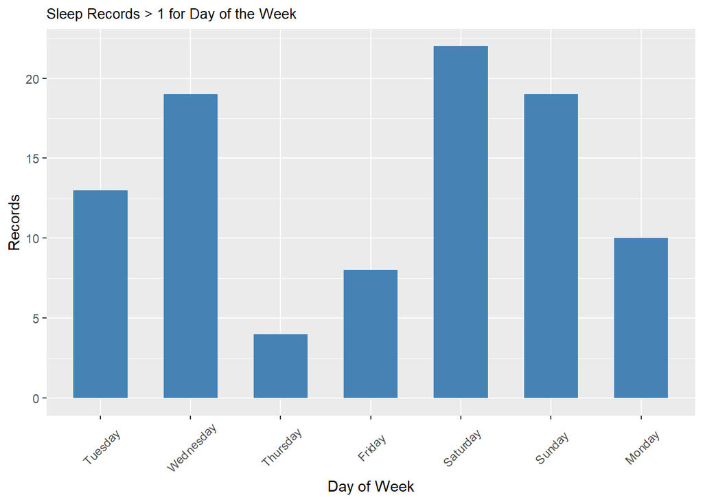

```r
# Number of Sleep Records > 1 for Day of the Week
sleepRecords <- filter(act_sleepDay, TotalSleepRecords > 1) %>%
  group_by(DayName) %>%
  summarise(TotalSleepRecords = sum(TotalSleepRecords))

ggplot(sleepRecords, aes(x=DayName, y = TotalSleepRecords)) +
   geom_bar(stat="identity", width=0.6,position = position_dodge(), fill="steelblue") +
  labs(x="Day of Week", y="Records") +
  ggtitle("Sleep Records > 1 for Day of the Week")+
  theme(plot.title = element_text(size = 10)) +
  theme(axis.text.x = element_text(angle = 45, vjust=+0.55))
```

#### Sleep Observations:

- There are 24 users worth of data which is less then the daily activity data which had 33 Ids
- The average time spent in bed is 458 minutes (7.6 hours) & the average time sleeping is 419 (7 hours) minutes
- Max time spent asleep occurred (796 mins) on a Monday
- Min time spent in bed occurred (58 mins) on a Sunday
- The least median time spent in bed is normally during the week with Tuesday having the smallest median.
- Participants spend the least median time asleep on a Friday
- Largest median time spent in bed and asleep is by far a Sunday. Bed & sleep times of greater than 600 minutes usually occurred on both a Saturday and Sunday. Minutes less than 600 minutes usually occurred from Friday to Sunday, so there are large variations in sleep patterns over weekends.
- Participants also tend to have more than one sleep occurrence on a weekend.
- The variation in weekend sleep patterns probably accounts for the absence of early scheduled working hours and large free time for eating out, entertaining, hobbies, family activities, etc. Perhaps people consider sleep at weekends as less important than working week days. At the same time, there’s more freedom to stay in bed longer at weekends.Overall lazy weekend appears to be true for many users with large variations in bed and sleep patterns.

#### Opportunities:

- Opportunity to provide app users a overview of their sleep patterns, identifying where and when they are not reaching their sleep targets and providing hints or suggestions on how they could improve, including which days of the week and for how long.

###### Most active Participants (Ids)

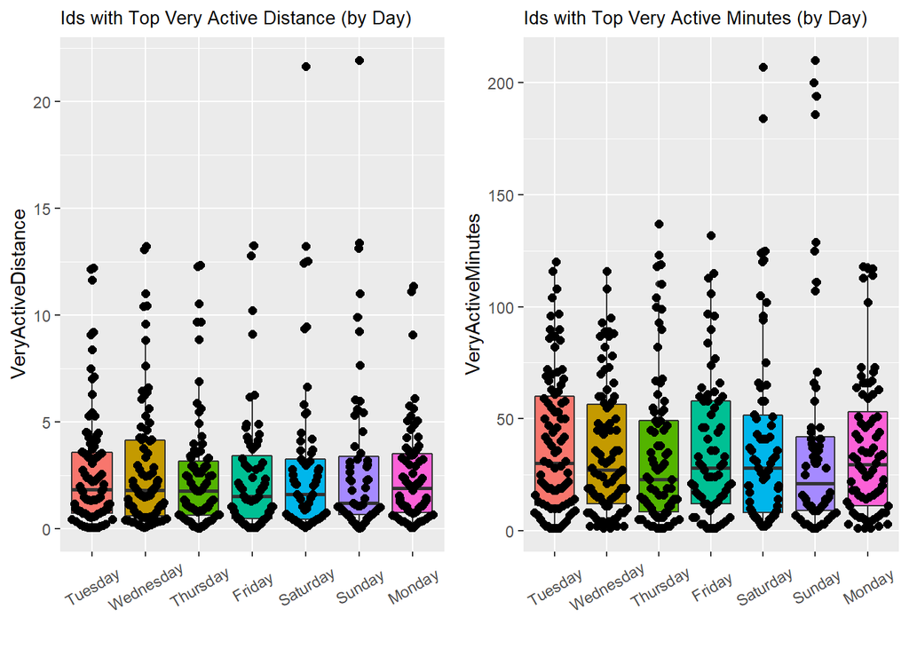

```r
# Remove zeros
ts <- dailyAct
ts[ts == 0] <- NA

g1 <- ggplot(ts, aes(x=DayName,y=VeryActiveDistance, fill=DayName)) +
  geom_boxplot() +
  labs(title="Ids with Top Very Active Distance (by Day)", x="") +
  geom_quasirandom(method = "smiley", cex=2) +
  theme(legend.position="none")+
  theme(plot.title = element_text(size = 10)) +
  theme(axis.text.x = element_text(angle = 30, vjust=+0.55))

g2 <- ggplot(ts, aes(x=DayName,y=VeryActiveMinutes, fill=DayName)) +
  geom_boxplot() +
  labs(title="Ids with Top Very Active Minutes (by Day)", x="") +
  geom_quasirandom(method = "smiley", cex=2) +
  theme(legend.position="none") +
  theme(plot.title = element_text(size = 10)) +
  theme(axis.text.x = element_text(angle = 30, vjust=+0.55))

grid.arrange(g1, g2,nrow=1, ncol=2)
```

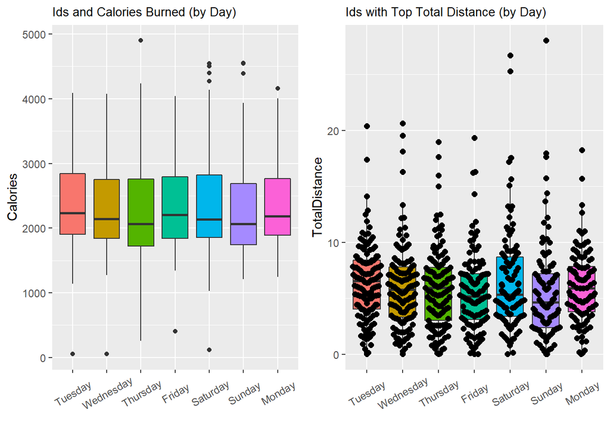

```
## [1] "Top Ids with very active distance"
```

```
##             Id VeryActiveDistance  DayName
## 51  1624580081              21.92   Sunday
## 928 8877689391              21.66 Saturday
## 795 8053475328              13.40   Sunday
```

```
## [1] "Top Ids with very active minutes"
```

```
##             Id VeryActiveMinutes  DayName
## 580 5577150313               210   Sunday
## 586 5577150313               207 Saturday
## 573 5577150313               200   Sunday
## 587 5577150313               194   Sunday
## 51  1624580081               186   Sunday
```

```
## [1] "Ids with the highest total Distance"
```

```
##             Id TotalDistance   DayName
## 51  1624580081         28.03    Sunday
## 928 8877689391         26.72  Saturday
## 914 8877689391         25.29  Saturday
## 925 8877689391         20.65 Wednesday
```

```
## [1] "Ids with the highest calories burned"
```

```
##             Id Calories  DayName
## 607 6117666160     4900 Thursday
## 573 5577150313     4552   Sunday
## 914 8877689391     4547 Saturday
## 587 5577150313     4546   Sunday
```

```r
g3 <- ggplot(ts, aes(x=DayName,y=Calories, fill=DayName)) +
  geom_boxplot() +
  labs(title="Ids and Calories Burned (by Day)", x="") +
  theme(legend.position="none") +
  theme(plot.title = element_text(size = 10)) +
  theme(axis.text.x = element_text(angle = 30, vjust=+0.55))

g4 <- ggplot(ts, aes(x=DayName,y=TotalDistance, fill=DayName)) +
  geom_boxplot() +
  labs(title='Ids with Top Total Distance (by Day)', x="") +
  geom_quasirandom(method = "smiley", cex=2) +
  theme(legend.position="none") +
  theme(plot.title = element_text(size = 10)) +
  theme(axis.text.x = element_text(angle = 30, vjust=+0.55))

grid.arrange(g3, g4,nrow=1, ncol=2)
```

#### Obervations

(most active Participants (Ids))

- Ids which are very active (in terms of minutes and distance) usually occurred on the weekend (Sat & Sun)
- Most active Ids are 5577150313, 1624580081 & 8877689391
- One participant (6117666160) managed to burn 4900 calories in one activity session on a Thursday

###### Daily Activity Correlations

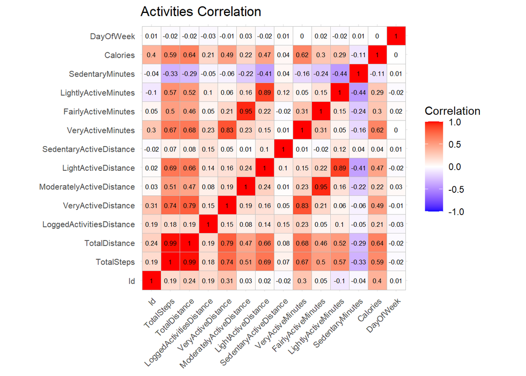

```r
# To allow us to view the correlation of dayName we can add dayName as a number
dailyAct$DayOfWeek <- as.integer(factor(dailyAct$DayName,
                                        levels=c("Tuesday","Wednesday","Thursday",
                                                  "Friday","Saturday","Sunday",
                                                  "Monday"),ordered=TRUE))

num.cols <- sapply(dailyAct, is.numeric) #returns numeric columns
# filter numeric columns only for correlation
numeric_dailyAct <- dailyAct[, num.cols]

# Visualise the correlations
ggcorrplot(cor(numeric_dailyAct), lab = TRUE,  lab_size = 2.3, legend.title = "Correlation",
           tl.cex = 8) +
  labs(title='Activities Correlation')
```

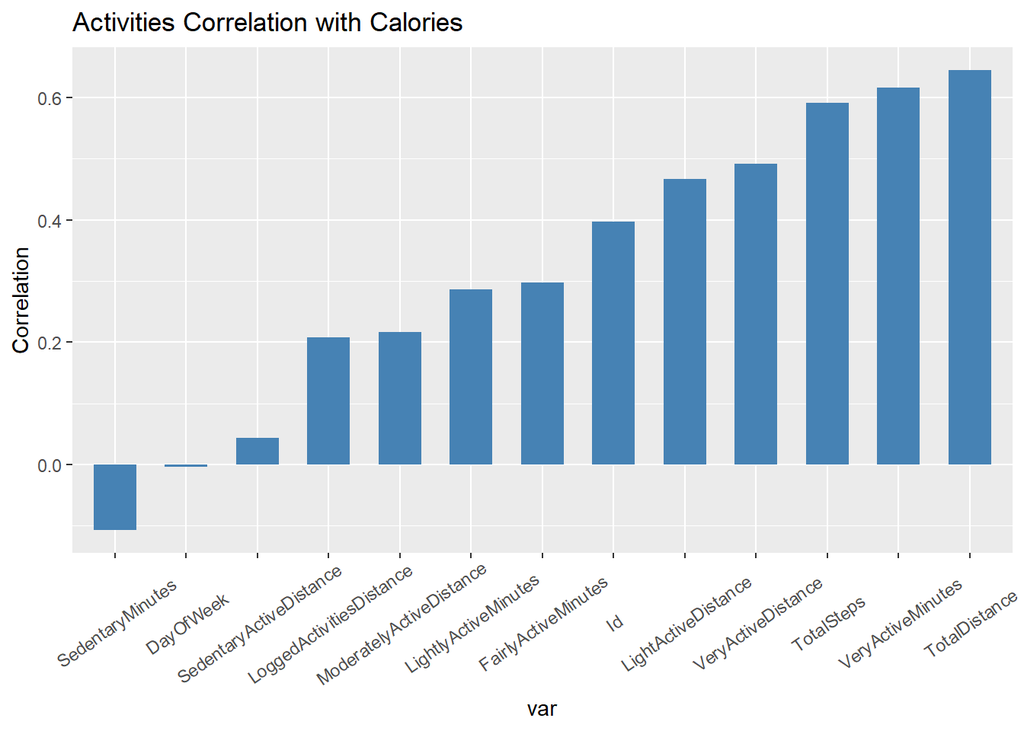

```r
# Visualise calories correlation
cor.data <- cor(dailyAct[, num.cols]) # correlations
cal.corr <- data.frame(var = colnames(cor.data),
                       calories = cor.data[,13]) # capture the 13th column only

cal.corr <- cal.corr[order(cal.corr$calories, decreasing = FALSE),]

# geom_bar plots in alphabetical order. Factorise to current order.
cal.corr$var <- factor(cal.corr$var,
                               levels = cal.corr$var)
cal.corr <- head(cal.corr,-1) # remove last row (calories)

ggplot(cal.corr, aes(x=var, y = calories)) +
  geom_bar(stat="summary", fun=sum, width=0.6, fill="steelblue") +
  labs(y="Correlation") +
  ggtitle("Activities Correlation with Calories") +
  theme(legend.position="none") +
  theme(axis.text.x = element_text(angle = 35, vjust=+0.55))
```

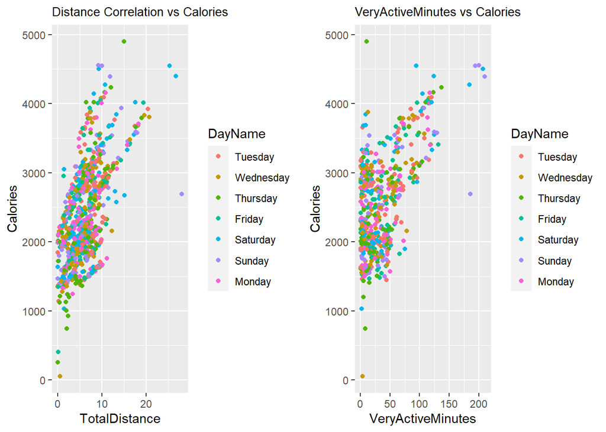

```r
# Scatter plots
h1 = ggplot(ts, aes(x = TotalDistance, y = Calories)) +
  geom_point(aes(color = factor(DayName))) +
  labs(color = "DayName") +
  theme(plot.title = element_text(size = 10)) +
  ggtitle("Distance Correlation vs Calories")

h2 = ggplot(ts, aes(x = VeryActiveMinutes, y = Calories)) +
  geom_point(aes(color = factor(DayName))) +
  labs(color = "DayName") +
  theme(plot.title = element_text(size = 10)) +
  ggtitle("VeryActiveMinutes vs Calories")

grid.arrange(h1, h2, nrow=1, ncol=2)
```

#### Observations

- If we look at correlations between most of the features, it’s basically the more steps taken, the greater the distance covered, and the higher level of activities, that will impact a person’s cardio levels, and the number of calories burned.
- There are many obvious strong positive correlations like TotalSteps/TotalDistance, and ModerateActiveDistance/FairlyActiveMinutes.
- Understandably TotalDistance, VeryActiveMinutes & TotalSteps are highly correlated with Calories
- Other variables are below 0.5 correlation with Calories
- light/fairly/moderate minutes and distance variables are less correlated with calories because they burn less calories.
- There’s some correlation between calories burned and Id, so some part participants are more actively burning calories than others and vice versa
- DayOfWeek is not correlated with Calories although we can see that high levels of distance and minutes usually occurs on a Saturday & Sunday.
- The scatter plots indicate a positive correlation with calories and TotalDistance & VeryActiveMinutes.

#### Opportunities:

- We can really promote the connection and importance of time spent exercising and the burning of calories and general fitness.
- We can show that moving from lightly/fairly activities to higher activity minutes and distance can impact calories burned, and general fitness and weight control.

###### Correlations (including sleep factors)

Note, sleep data has less data points (24 participants)

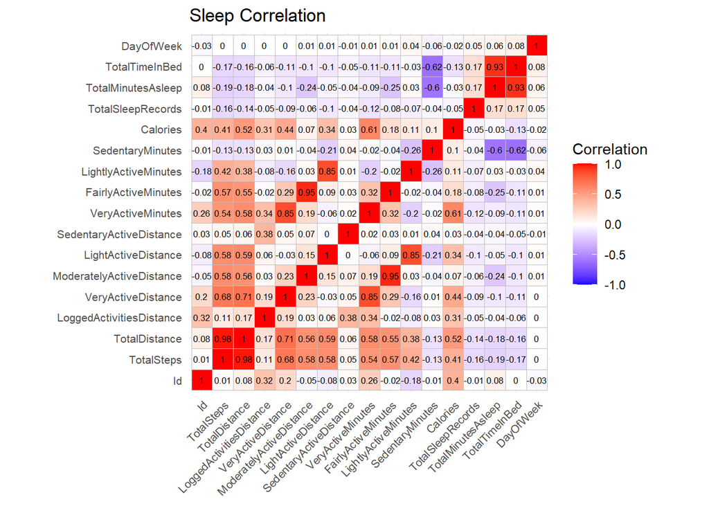

```r
# add DayOfWeek - to view correlation with sleep factors
# to allow us to view the correlation of dayName we can add dayName as a factor
act_sleepDay$DayOfWeek <- as.integer(factor(act_sleepDay$DayName,
                                      levels=c("Tuesday","Wednesday","Thursday", "Friday",
                                               "Saturday","Sunday","Monday"),ordered=TRUE))

num.cols_2 <- sapply(act_sleepDay, is.numeric) # returns numeric columns
# filter numeric columns only for correlation
numeric_sleep <- act_sleepDay[, num.cols_2]

# Visualise the correlations
ggcorrplot(cor(numeric_sleep), lab = TRUE, lab_size = 2.3, legend.title = "Correlation",
           tl.cex = 8) +
  labs(title='Sleep Correlation')
```

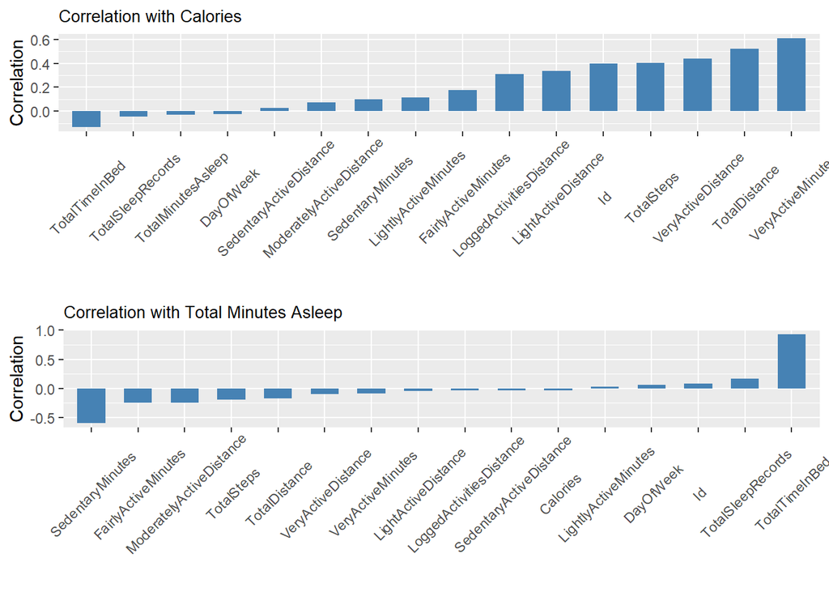

```r
# Visualise calories correlation
cor.sleep <- cor(numeric_sleep) # correlations
cal.cor_df <- data.frame(var = colnames(cor.sleep),
                       calories = cor.sleep[,13],
                       TotalMinutesAsleep = cor.sleep[,15]) # capture the 13th column

# Order to Calories
cal.cor_sleep <- cal.cor_df[order(cal.cor_df$calories, decreasing = FALSE),]

# geom_bar plots in alphabetical order. Factorize to current order.
cal.cor_sleep$var <- factor(cal.cor_sleep$var,
                       levels = cal.cor_sleep$var)

# remove last row (calories)
cal.cor_sleep <- head(cal.cor_sleep,-1)


# Visualise Sleep Correlation
# Order to Sleep
tot.cor_sleep <- cal.cor_df[order(cal.cor_df$TotalMinutesAsleep, decreasing = FALSE),]

# geom_bar plots in alphabetical order. Factorize to current order.
tot.cor_sleep$var <- factor(tot.cor_sleep$var,
                            levels = tot.cor_sleep$var)
# remove last row (Sleep)
tot.cor_sleep <- head(tot.cor_sleep,-1)

i1 <- ggplot(cal.cor_sleep, aes(x=var, y = calories)) +
  geom_bar(stat="summary", fun=sum, width=0.6, fill="steelblue") +
  labs(y="Correlation", x ="") +
  ggtitle("Correlation with Calories") +
  theme(plot.title = element_text(size = 10)) +
  theme(legend.position="none") +
  theme(axis.text.x = element_text(angle = 45, vjust=+0.55))

i2 <- ggplot(tot.cor_sleep, aes(x=var, y = TotalMinutesAsleep)) +
  geom_bar(stat="summary", fun=sum, width=0.6, fill="steelblue") +
  labs(y="Correlation", x="") +
  ggtitle("Correlation with Total Minutes Asleep") +
  theme(plot.title = element_text(size = 10)) +
  theme(legend.position="none") +
  theme(axis.text.x = element_text(angle = 45, vjust=+0.55))

grid.arrange(i1, i2, nrow=2, ncol=1)
```

#### Obervations:

- Sleep data has less data points (24 participants) than the daily activity data set
- There’s a little correlation (-0.25) between levels of activity and time spent sleeping but it’s not significant. So users that stayed in bed less are not particularly more active during the day. Although there is no significant correlation between time spent in bed and calories burned throughout the day, it is higher than minutes spent sleeping and calories burned.

###### Which Id enjoys time in bed and sleeping

```r
dat_records_2 <- filter(act_sleepDay, TotalSleepRecords > 1) %>%
  group_by(Id) %>%
  summarise(TotalSleepRecords = sum(TotalSleepRecords))

bedTime <- act_sleepDay %>% group_by(Id) %>%
  summarise(TotalTimeInBed = median(TotalTimeInBed))

sleepTime <- act_sleepDay %>% group_by(Id) %>%
  summarise(TotalMinutesAsleep = median(TotalMinutesAsleep))

topsleepers <- act_sleepDay %>% group_by(Id) %>%
  summarise(TotalTimeInBed = sum(TotalTimeInBed),
            TotalMinutesAsleep = sum(TotalMinutesAsleep))
topsleepers <- melt(topsleepers, id.vars = "Id", variable.name="var")
```

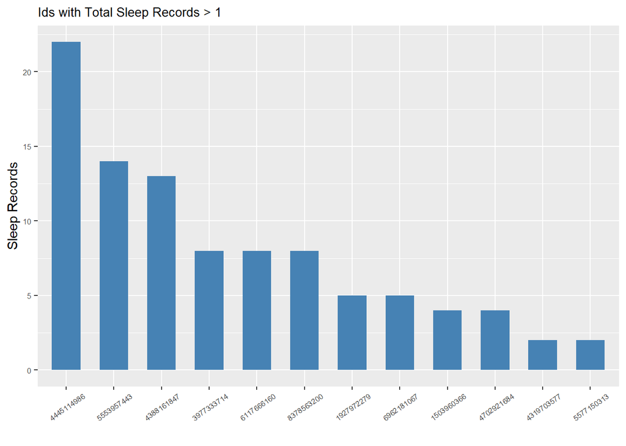

```r
ggplot(dat_records_2, aes(x=reorder(factor(Id), -TotalSleepRecords), y = TotalSleepRecords)) +
  geom_bar(fill="steelblue",stat="identity", width=0.6,position = position_dodge()) +
  labs(x="", y="Sleep Records") +
  ggtitle("Ids with Total Sleep Records > 1") +
  theme(plot.title = element_text(size = 10)) +
  theme(axis.text.x = element_text(angle = 35, vjust=+0.55),
        axis.text=element_text(size=6))
```

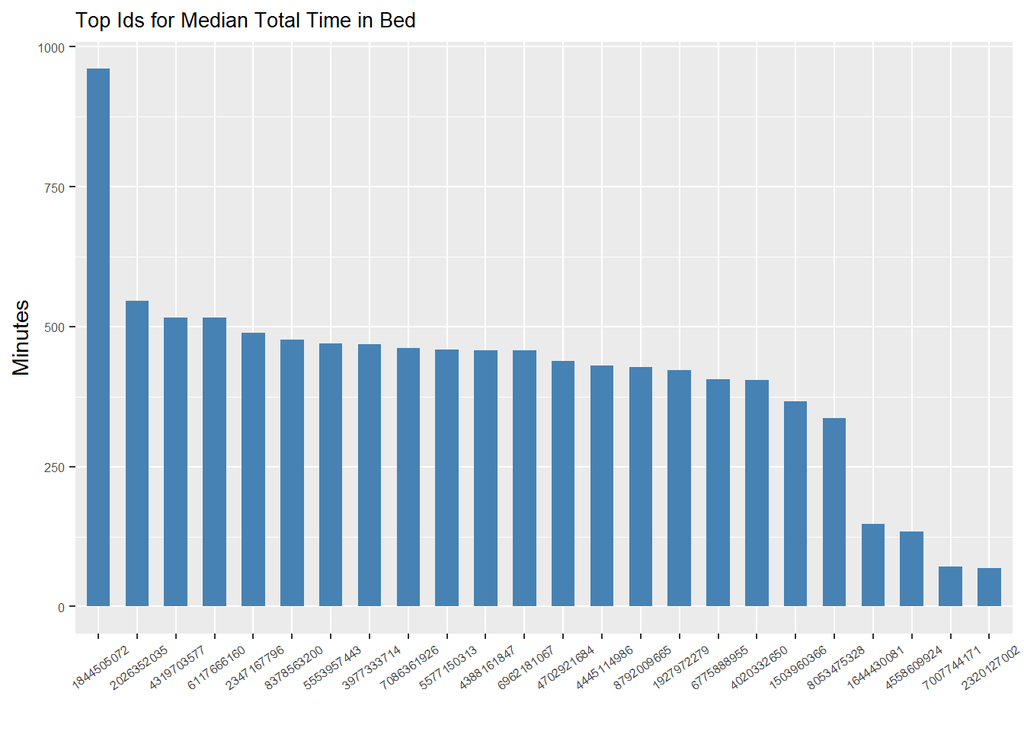

```r
ggplot(bedTime, aes(x=reorder(factor(Id), -TotalTimeInBed), y = TotalTimeInBed)) +
  geom_bar(stat="identity", width=0.6,position = position_dodge(), fill="steelblue") +
  labs(x="", y="Minutes") +
  ggtitle("Top Ids for Median Total Time in Bed") +
  theme(plot.title = element_text(size = 10)) +
  theme(axis.text.x = element_text(angle = 35, vjust=+0.55),
        axis.text=element_text(size=6))
```

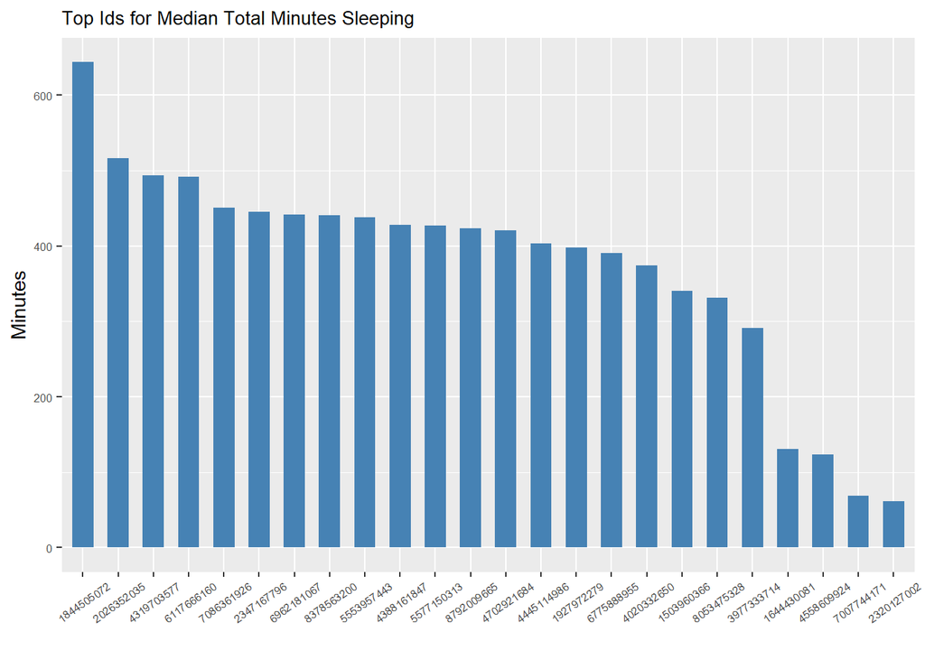

```r
ggplot(sleepTime, aes(x=reorder(factor(Id), -TotalMinutesAsleep), y = TotalMinutesAsleep)) +
  geom_bar(stat="identity", width=0.6,position = position_dodge(), fill="steelblue") +
  labs(x="", y="Minutes") +
  ggtitle("Top Ids for Median Total Minutes Sleeping") +
  theme(plot.title = element_text(size = 10)) +
  theme(axis.text.x = element_text(angle = 35, vjust=+0.55),
        axis.text=element_text(size=6))
```

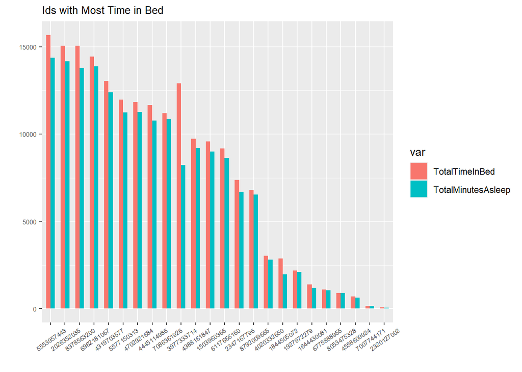

```r
ggplot(topsleepers, aes(reorder(x=factor(Id), -value), y = value, fill=var)) +
  geom_bar(stat="identity", width=0.6,position = position_dodge()) +
  labs(x="", y="") +
  ggtitle("Ids with Most Time in Bed") +
  theme(plot.title = element_text(size = 10)) +
  theme(axis.text.x = element_text(angle = 35, vjust=+0.55),
        axis.text=element_text(size=6))
```

###### User activity patterns

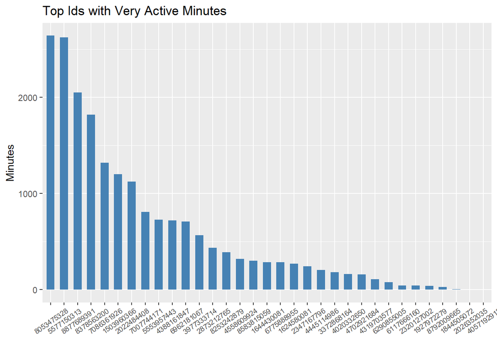

```r
# Very Active Minutes
dailyAct_order1 <- dailyAct %>% group_by(Id) %>%
  summarise(VeryActiveMinutes = sum(VeryActiveMinutes))

# Very Active Distance
dailyAct_order2 <- dailyAct %>% group_by(Id) %>%
  summarise(VeryActiveDistance = sum(VeryActiveDistance))

# Total Distance
dailyAct_order3 <- dailyAct %>% group_by(Id) %>%
  summarise(TotalDistance = sum(TotalDistance))

# Total Steps
dailyAct_order4 <- dailyAct %>% group_by(Id) %>%
  summarise(TotalSteps = sum(TotalSteps))

ggplot(dailyAct_order1, aes(reorder(x=factor(Id), -VeryActiveMinutes), y = VeryActiveMinutes))+
  geom_bar(stat="identity", width=0.6, fill="steelblue") +
  labs(y="Minutes", x="") +
  ggtitle("Top Ids with Very Active Minutes") +
  theme(legend.position="none") +
  theme(axis.text.x = element_text(size = 7, angle = 35, vjust=+0.55))
```

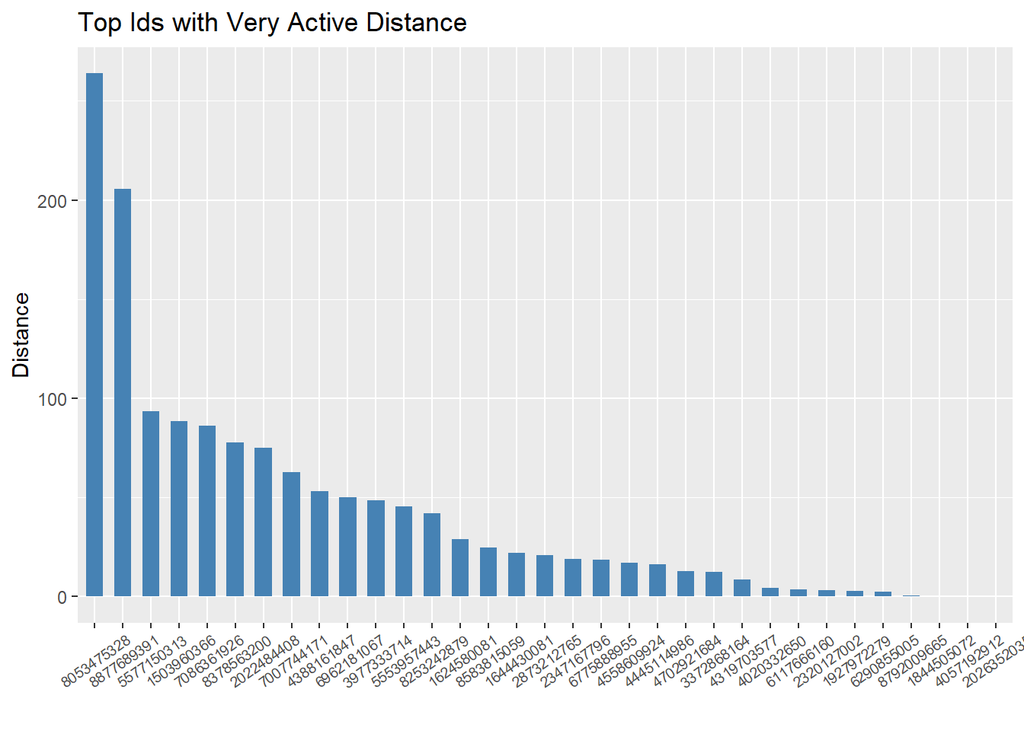

```r
ggplot(dailyAct_order2, aes(reorder(x=factor(Id), -VeryActiveDistance), y = VeryActiveDistance)) +
  geom_bar(stat="identity", width=0.6, fill="steelblue") +
  labs(y="Distance", x="") +
  ggtitle("Top Ids with Very Active Distance") +
  theme(legend.position="none") +
  theme(axis.text.x = element_text(size = 7, angle = 35, vjust=+0.55))
```

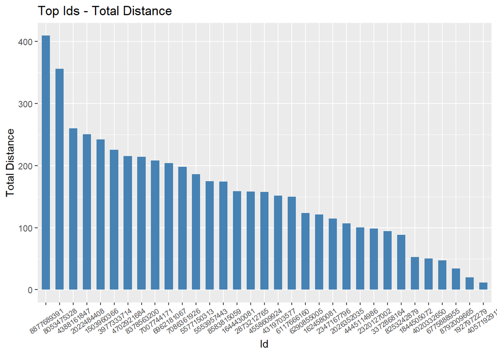

```r
ggplot(dailyAct_order3, aes(reorder(x=factor(Id), -TotalDistance), y = TotalDistance)) +
  geom_bar(stat="identity", width=0.6, fill="steelblue") +
  labs(y="Total Distance", x="Id") +
  ggtitle("Top Ids - Total Distance") +
  theme(legend.position="none") +
  theme(axis.text.x = element_text(size = 7, angle = 35, vjust=+0.55))
```

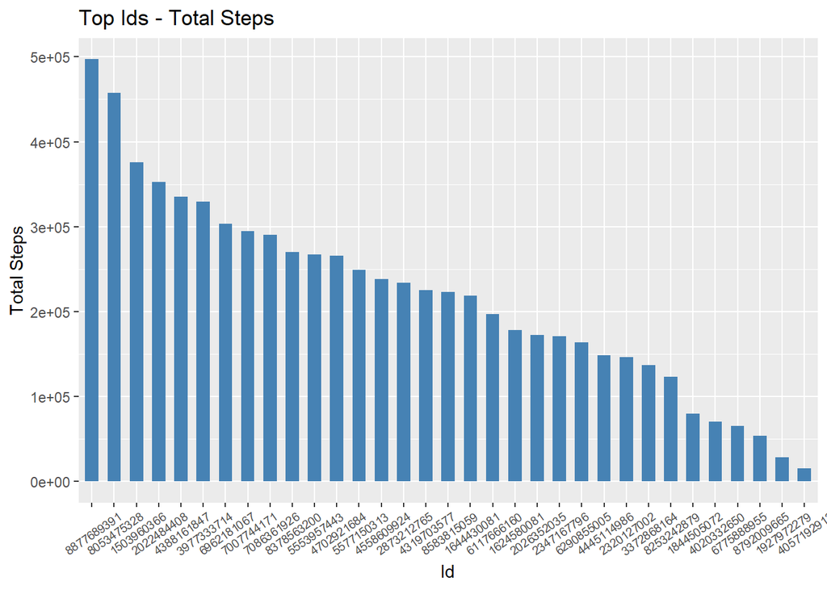

```r
ggplot(dailyAct_order4, aes(reorder(x=factor(Id), -TotalSteps), y = TotalSteps)) +
  geom_bar(stat="identity", width=0.6, fill="steelblue") +
  labs(y="Total Steps", x="Id") +
  ggtitle("Top Ids - Total Steps") +
  theme(legend.position="none") +
  theme(axis.text.x = element_text(size = 7, angle = 35, vjust=+0.55))
```